# Cyclistic

Valeria Jimenez

2023-12-04

### Introduction

Cyclistic Bike Share is a bike-share program looking to maximize annual memberships. **The goal is to find out how members differ from casual (non-annual members) riders.**

### Summary of Analysis

- Key Findings - Casual riders
  - Casual riders ride more on weekends
  - Weekends: rides peak in the afternoon with normal distribution
  - Casual riders have much longer ride lengths (roughly twice as long)
  - Most popular start and end station: Streeter Dr & Grand Ave
  - Casual riders ride more in the peak Summer period and ride less in the low Winter period than members
- Key Findings - Members
  - Members ride more on weekdays
  - Weekdays: rides peak at rush hour
  - Most popular start and end station: Clark St & Elm St
- Key Findings - General
  - Regardless of membership status, ridership peaks in the Summer (June to September) and hits an all time low during Winter (November to February)

### Visualizations and Findings

#### Package Imports

```r
library(tidyverse)
library(janitor)
library(lubridate)
```

#### Import CSVs and merge into a dataframe

Data from Google Data Analytics Course

```r
jan2021 <- read_csv('divvy_monthlytripdata/202101-divvy-tripdata.csv')
feb2021 <- read_csv('divvy_monthlytripdata/202102-divvy-tripdata.csv')
mar2021 <- read_csv('divvy_monthlytripdata/202103-divvy-tripdata.csv')
apr2021 <- read_csv('divvy_monthlytripdata/202104-divvy-tripdata.csv')
may2021 <- read_csv('divvy_monthlytripdata/202105-divvy-tripdata.csv')
jun2021 <- read_csv('divvy_monthlytripdata/202106-divvy-tripdata.csv')
jul2021 <- read_csv('divvy_monthlytripdata/202107-divvy-tripdata.csv')
aug2021 <- read_csv('divvy_monthlytripdata/202108-divvy-tripdata.csv')
sep2021 <- read_csv('divvy_monthlytripdata/202109-divvy-tripdata.csv')
oct2021 <- read_csv('divvy_monthlytripdata/202110-divvy-tripdata.csv')
nov2021 <- read_csv('divvy_monthlytripdata/202111-divvy-tripdata.csv')
dec2021 <- read_csv('divvy_monthlytripdata/202112-divvy-tripdata.csv')

entire_dataset <- list(jan2021, feb2021, mar2021, apr2021, may2021, jun2021, jul2021, aug2021, sep2021, oct2021, nov2021, dec2021)

for (dataset in entire_dataset) {
  str(dataset)
}

merged_df <- bind_rows(entire_dataset)
merged_df <- clean_names(merged_df)
merged_df <- remove_empty(merged_df, which = c())
```

#### Add features to aid analysis

```r
merged_df$day_of_week <- wday(merged_df$started_at, label = T, abbr = T)
merged_df$starting_hour <- format(as.POSIXct(merged_df$started_at), '%H')
merged_df$month <- format(as.Date(merged_df$started_at), '%m')
merged_df$ride_length <- difftime(merged_df$ended_at, merged_df$started_at, units = 'sec')
clean_df <- merged_df[!(merged_df$ride_length <= 0),]
```

#### Export CSV

```r
write.csv(clean_df, file = 'cyclistic_df.csv')
```

### How do casual riders differ from members?

- Number of Rides per Week

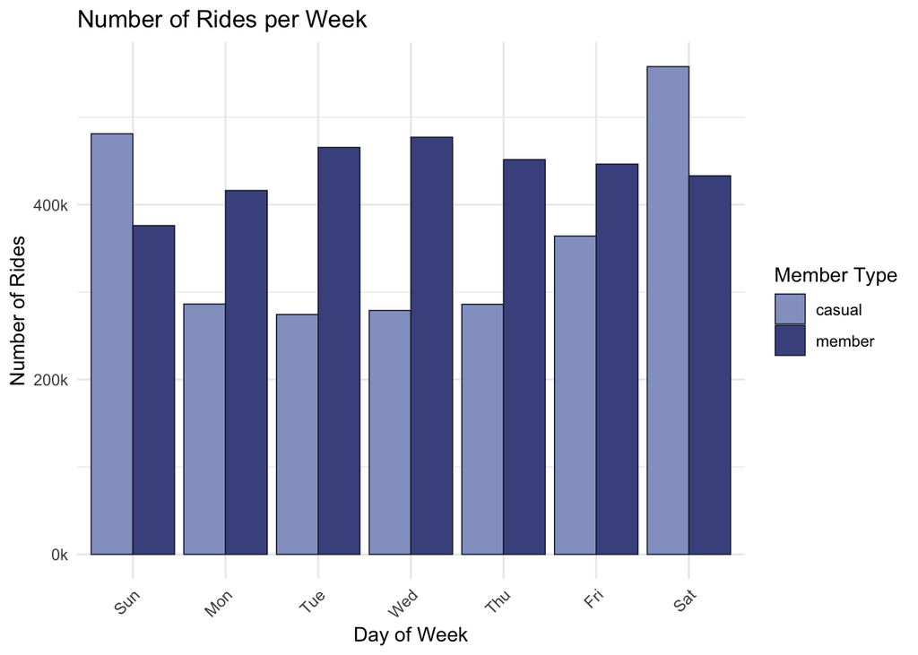

- Number of Rides per Month

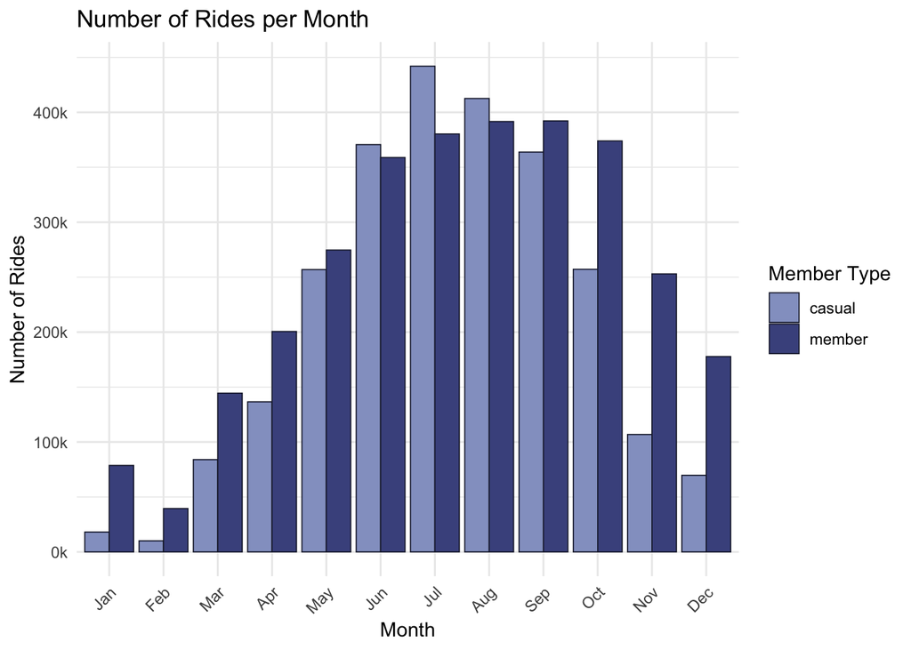

- Hourly Rides per Weekday

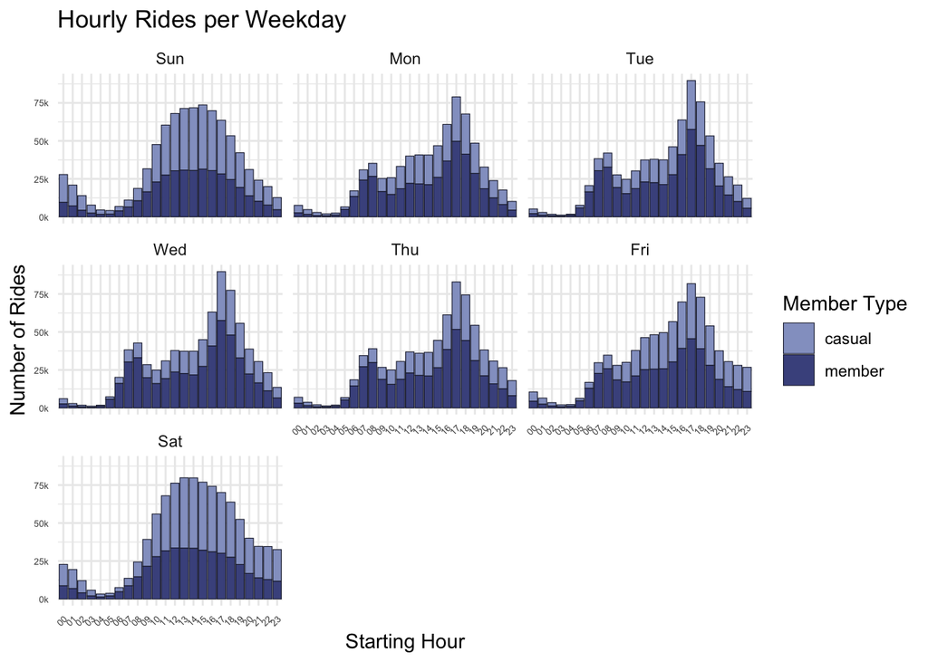

- Average Trip Duration for Casual Riders and Members

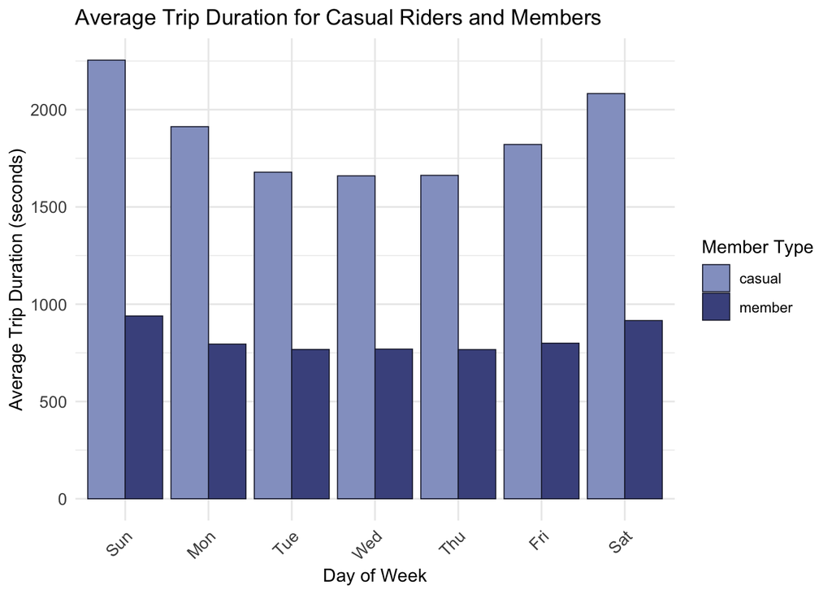

- Top Start and End Stations

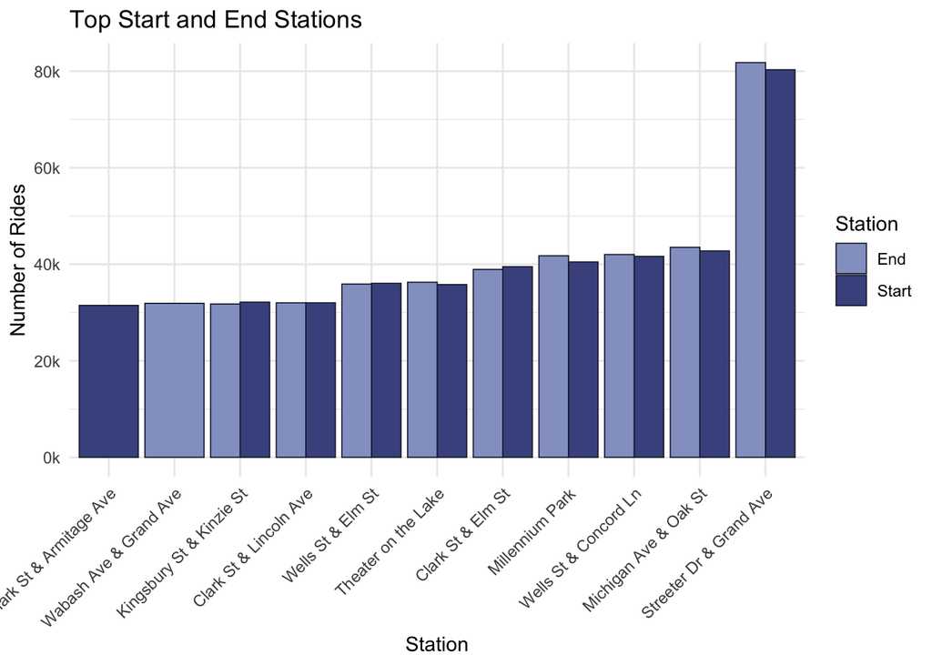

- Top Start and End Stations (Members)

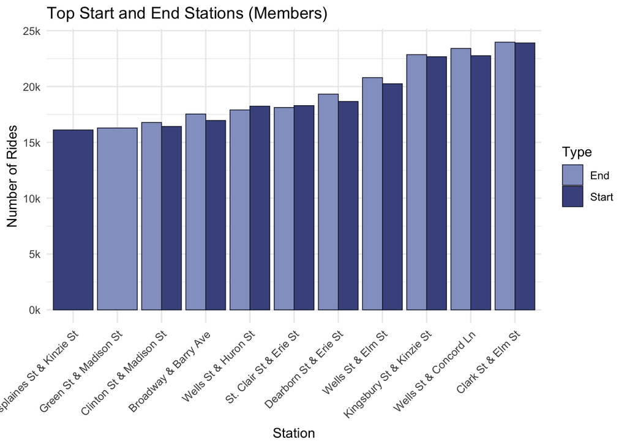

- Top Start and End Stations (casual riders)

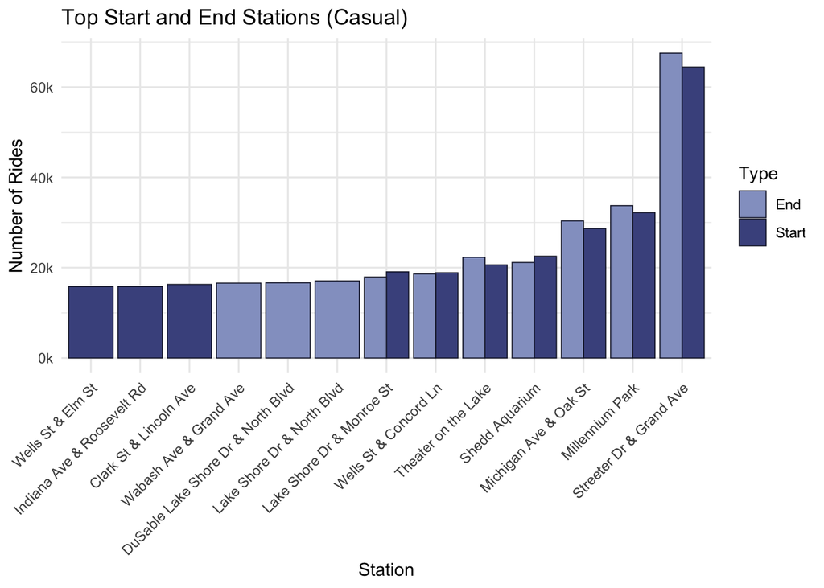

- Number of rides by month

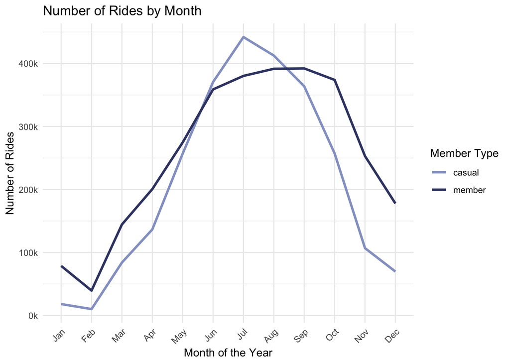

### Hypotheses

- Members are mostly commuters using the bike share in order to get to and from work
- Casual riders (many might be tourists) use the bike share for recreational long weekend rides
- Ridership falls in the winter due to cold temperatures (hypothesis could be strengthened with weather data)

### Recommendations

1. Target casual **weekend** riders and encourage them to become members by **introducing weekend memberships**.
2. Target casual **weekday** riders and encourage commuting via bike share by **introducing special rush hour memberships**.
3. **Reward casual riders with long bike rides** and encourage them to switch to a membership.
4. Continue to promote annual memberships at the stations most popular with current annual members in order to **target potential commuters/members**.
5. Investigate why Streeter Dr & Grand Ave is so popular with casual riders.
6. **Adjust membership plans (ie. seasonal plans)** in order to account for Summer spikes and Winter dips. Spend more on marketing in the Summer months.
7. Create general incentives to encourage members to remain members and casual riders to convert - for example, **a small non-member surcharge on all casual rides**.